# Besemah stress

A basic example

Bradley McDonnell

12/29/2018

```
## # A tibble: 6 x 13
##   WordOrder Word  Participant Position Vowel Weight Focus   Final Duration
##       <int> <fct> <fct>       <fct>    <fct> <fct>  <fct>   <fct>    <dbl>
## 1         1 tutus S1          penult   u     light  in-foc… final   0.0754
## 2         1 tutus S1          ultima   u     light  in-foc… final   0.189
## 3         3 tatap S1          penult   a     light  in-foc… final   0.0697
## 4         3 tatap S1          ultima   a     light  in-foc… final   0.149
## 5         4 pipis S1          penult   i     light  in-foc… final   0.0799
## 6         4 pipis S1          ultima   i     light  in-foc… final   0.213
## # ... with 4 more variables: F0 <dbl>, H1H2 <dbl>, Intensity <dbl>,
## #   SpectralBalance <dbl>
```

# Introduction

There has been much disagreement over the status of word-level stress in the languages of western Indonesia, particularly in regards to well-known varieties of Malay, such as Standard Indonesian (van Zanten, Goedemans, and Pacilly 2003).[^1] Word-level stress has been claimed to fall predictably on the penultimate syllable unless it contains a schwa in which case it falls on the ultima (Adisasmito-Smith and Cohn 1996). However, since the late 1990s, an increasing number of studies have questioned this position for Standard Indonesian (van Zanten and van Heuven 2004), and more recent studies have pointed out the complications associated with studies of Standard Indonesian due to significant influence from substrate languages like Javanese (Goedemans and van Zanten 2007).

The present study is designed to tease apart different factors relating to prosodic prominence in Besemah. It does so by investigating the realization of common acoustic correlates of stress (f$_0$, duration, intensity, and spectral tilt) within target words that vary in their sentence position (sentence-medial vs. sentence-final position) and information status (‘in focus’ vs. ‘out of focus’).

## Besemah word level stress

Like many of the languages of western Indonesia, Besemah has received little attention since the Dutch colonial period (McDonnell 2008). The only study of Besemah prosody tentatively concluded that word-level stress in Besemah falls on the final syllable of the word and is cued by increased intensity (McDonnell 2016). However, there are several complications to this analysis, and word-level stress appears to be affected by the presence of final L boundary tones.

# Methods

This section describe the methodology used in this study.

## Design

Target words were collected using an information gap task. This task involved two talkers: a confederate who asked questions and a naive participant who answered them. They sat facing each other, each able to see only their own laptop screen. Both the confederate and participant could see a question on the top of the screen that the confederate was to ask, but only the participant’s screen displayed the answer.The task was for the confederate to ask the question and the participant to provide an answer in a complete sentence modeled upon the question. The confederate then circled the answer on the paper. One female native speaker of Besemah acted as the confederate for all participants.

## Materials

Question-answer pairs were constructed which varied in information status (target word ‘in focus’ or ‘out of focus’) and sentence position (target word sentence-medial or sentence-final). The type and structure of the question depended upon the combination of its sentence position and information status. Question type differed based upon whether the target word was ‘in focus’ or ‘out of focus.’[^2] The sentence position simply altered the shape of the question so that the target word would occur in sentence-medial or sentence-final position. The table below presents example question-answer pairs for the ‘in focus’ condition. In this table the target word *susu* ‘milk’ is used as an example and displayed in boldface.

Information status condition

| **Position** |  | **Question/Answer** |
| --- | --- | --- |
| final | Q: | *Sebelah kanan kate ape?* |
|  |  | ‘On the right side is what word?’ |
|  | A: | *Sebelah kanan kate **susu**.* |
|  |  | ‘On the right side is **milk**.’ |
| medial | Q: | *Kate ape sebelah kanan?* |
|  |  | ‘What word is on the right side?’ |
|  | A: | *Kate* *susu* *sebelah kanan.* |
|  |  | ‘The word **milk** is on the right side.’ |

The twelve target words are shown in the table below. Syllables in Besemah are maximally CVC with some restrictions on the coda consonants and words are most commonly bisyllabic. The words feature all four phonotactically legal combinations of light (CV) and heavy (CVC) syllables. Each of the four vowels /i, u, a, ə/ was present and matched in both syllables to allow for easier intra-word comparisons. Phonotactically, the high vowels /i, u/ show no restrictions, but /a/ does not occur word-finally and /ə/ does not occur in final closed syllables.

Target words used in constructing question-answer pairs.

| **Phoneme** | **Word** | **Meaning** |
| --- | --- | --- |
| /i/ | /titi/ | ‘to cross over’ |
|  | /pipis/ | ‘to pulverize’ |
|  | /tʃiŋki/ | ‘must have’ |
|  | /sintiŋ/ | ‘crooked’ |
| /u/ | /susu/ | ‘milk’ |
|  | /tutus/ | ‘to pound’ |
|  | /tuŋku/ | ‘hearth’ |
|  | /tuntun/ | ‘to watch’ |
| /a/ | — |  |
|  | /tatap/ | ‘to touch’ |
|  | — |  |
|  | /pantas/ | ‘to be fitting’ |
| /ə/ | /tʃətə/ | ‘to be exact’ |
|  | — |  |
|  | /təmpə/ | ‘to forge’ |
|  | — |  |

## Procedure

All recordings were made on a Marantz PMD-670 solid state recorder with a sampling frequency of 48kHz and stored as wav files. The participant was recorded on the left channel with a Shure WH-30 headset microphone while the confederate was recorded on the right channel with a Shure SM10A headset microphone.

Each target word was repeated four times for each of the four blocks (12 words $\times$ 4 repetitions $\times$ 4 blocks = 192 tokens). The presentation of these words was randomized and the presentation of each block was also randomized.

## Participants

The experiment was conducted by the first author over several days in March~2015 in the Besemah village of Karang Tanding. The experiment was conducted entirely in Besemah with no interlanguage. The six female participants in this study are native speakers of Besemah and reside in or near the village of Karang Tanding in South Sumatra province. They range in age from 19 to 30 years old.

# Acoustic correlates of stress

This section takes a preliminary look at the acoustic correlates of stress in Besemah.

## Duration

Duration in the final syllable appears to be longer compared to duration of the penultimate syllable. It is noteworthy, however, that while duration may be the most robust correlate for stress, it is confounded with word-final lengthening.

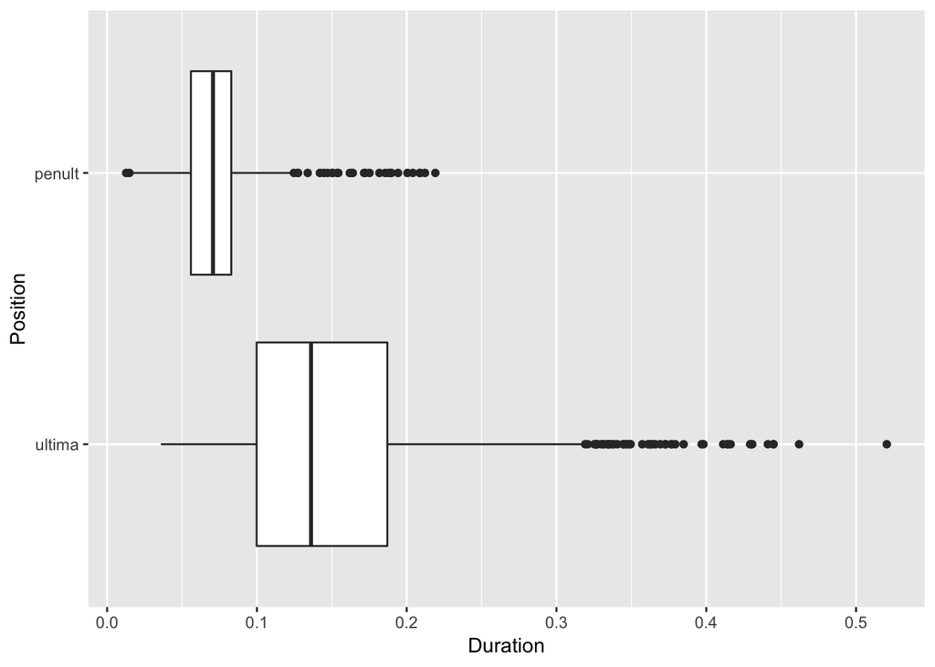

As expected, when the word is in the final position in the sentence, the duration is longer in the ultimae. The penult appears to be fairly similar whether or not the word is sentence final or not.

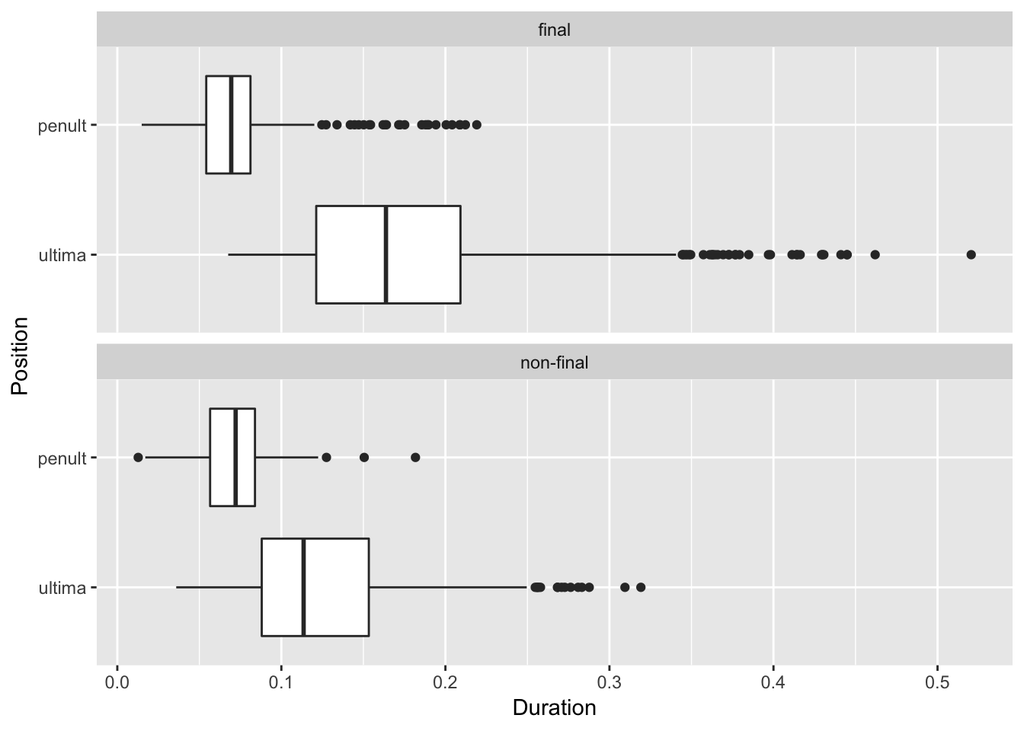

The fairly simple table below shows the mean duration for penult and final syllables. It is clear that the ultima is longer.

| Position | Duration |
| --- | --- |
| penult | 0.070 |
| ultima | 0.152 |

[output not shown]

This more complex table below demonstrates the mean duration for each of the six participants in both sentence final and sentence medial positions.

| Participant | Final | Position | Duration |
| --- | --- | --- | --- |
| S1 | final | penult | 0.077 |
|  |  | ultima | 0.262 |
|  | non-final | penult | 0.081 |
|  |  | ultima | 0.134 |
| S2 | final | penult | 0.094 |
|  |  | ultima | 0.221 |
|  | non-final | penult | 0.075 |
|  |  | ultima | 0.117 |
| S3 | final | penult | 0.067 |
|  |  | ultima | 0.128 |
|  | non-final | penult | 0.073 |
|  |  | ultima | 0.142 |
| S4 | final | penult | 0.053 |
|  |  | ultima | 0.127 |
|  | non-final | penult | 0.053 |
|  |  | ultima | 0.105 |
| S5 | final | penult | 0.066 |
|  |  | ultima | 0.174 |
|  | non-final | penult | 0.071 |
|  |  | ultima | 0.080 |
| S6 | final | penult | 0.066 |
|  |  | ultima | 0.161 |
|  | non-final | penult | 0.069 |
|  |  | ultima | 0.177 |

## Intensity

The interaction between sentence position and intensity is very similar across speakers. Speakers show the same pattern: the ultima is more intense when it is in non-final sentence position.

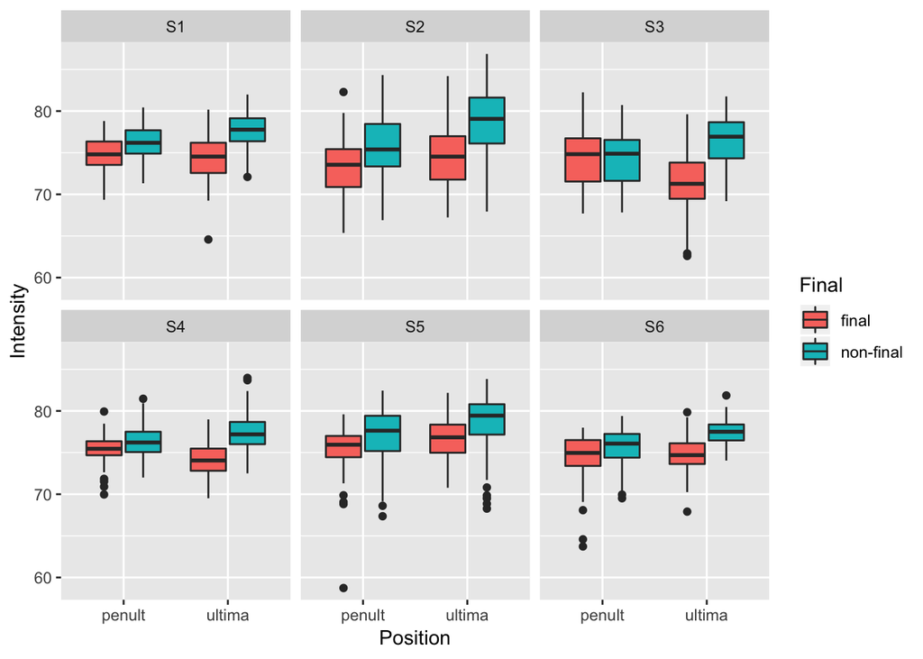

# Conclusion

There are some interesting data here, but we cannot conclude much at this point.

# References

Adisasmito-Smith, Niken, and Abigal C. Cohn. 1996. “Phonetic Correlates of Primary and Secondary Stress in Indonesian: A Preliminary Study.” *Working Papers of the Cornell Phonetics Laboratory* 11: 1–15.

Goedemans, Robertus Wilhelmus Nicolaas, and Ellen van Zanten. 2007. “Stress and Accent in Indonesian.” In *Prosody in Indonesian Languages*, edited by Vincent J van Heuven and Ellen van Zanten, 35–62. Utrecht: LOT.

McDonnell, Bradley. 2008. “A Conservative Vowel Phoneme Inventory of Sumatra: The Case of Besemah.” *Oceanic Linguistics* 47 (2): 409–32.

———. 2016. “Acoustic Correlates of Stress in Besemah.” In *NUSA: Linguistic Studies of Languages in and Around Indonesia, Studies in Language Typology and Change*, edited by Timothy McKinnon and Yanti, 60:1–28.

Roberts, Craige. 2012. “Information Structure in Discourse: Towards an Integrated Formal Theory of Pragmatics.” *Semantics and Pragmatics* 5 (6): 1–69. doi:10.3765/sp.5.6.

Schwarzschild, Roger. 1999. “GIVENness, AvoidF and Other Constraints on the Placement of Accent.” *Natural Language Semantics* 7: 141–77.

van Zanten, Ellen, and Vincent J. van Heuven. 2004. “Word Stress in Indonesian: Fixed or Free.” *NUSA, Linguistic Studies of Indonesian and Other Languages in Indonesia* 53: 1–20.

van Zanten, Ellen, Robertus Wilhelmus Nicolaas Goedemans, and Jos J.A. Pacilly. 2003. “The Status of Word Stress in Indonesian.” In *The Phonological Spectrum: Suprasegmental Structure*, edited by Jeroen van de Weijer, Vincent J. van Heuven, and Harry van der Hulst, 151–75. Amsterdam: John Benjamins.

[^1]: Text from this example is lifted directly from McDonnell & Turnbull (2018).
[^2]: ‘Focus’, as a term of art in linguistics, is fraught with definitional difficulties. In our ‘in focus’ condition, the target word is the answer to the current question under discussion (Roberts 2012). In the ‘out of focus’ condition, on the other hand, the target word is given, not new (Schwarzschild 1999). This definition may not match exactly with the definitions used by other researchers, and we invite the reader to mentally substitute their favorite terms that fit their proclivities if they are so inclined.